# Assignment 3: Clustering using decision trees and logistic regression

## Q1: Create an instance of Decision Tree Classifier, set max_depth = 1.

Fill in the below code, and fit the dataset to the model.

```python
from sklearn.tree import DecisionTreeClassifier

y_train = df["Class"]
x_train = df.drop(['Name','Class'],axis=1)

clf = DecisionTreeClassifier(criterion='entropy',random_state=0, max_depth= 1)
clf.fit(x_train, y_train)
```

```
DecisionTreeClassifier(criterion='entropy', max_depth=1, random_state=0)
```

#### What are the parameters of our clf object?

```python
clf.__init__
```

```
<bound method DecisionTreeClassifier.__init__ of DecisionTreeClassifier(criterion='entropy', max_depth=1, random_state=0)>
```

### Plotting decision trees

An advantage of decision trees is that we can use a decision tree plot to visualize the rules developed by the tree. If you don't already have graphviz and pydotplus, please download using "pip install" with library name (more about these libraries at http://www.graphviz.org and http://pydotplus.readthedocs.io/)

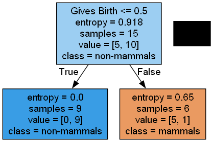

```python
import pydotplus
from IPython.display import Image
from sklearn import tree
dot_data = tree.export_graphviz(clf, feature_names=x_train.columns
                , class_names=['mammals','non-mammals'],filled=True)
graph = pydotplus.graph_from_dot_data(dot_data)
Image(graph.create_png())
```

## Q2: Create an instance of Decision Tree Classifier, with max_depth=3.

Discuss the results, what is different about the decision tree, and why?

```python
clf_depth3 = DecisionTreeClassifier(criterion='entropy',random_state=0, max_depth= 3)
clf_depth3.fit(x_train, y_train)
```

```
DecisionTreeClassifier(criterion='entropy', max_depth=3, random_state=0)
```

Depth of the trees:

Entropy:

- In the first tree, the 'False' branch after the first split has an entropy of 0.65, indicating some impurity. In the second tree, this branch is further split by the "Warm-blooded" feature, creating two new branches, each with an entropy of 0, indicating that they are perfectly pure.

Samples and Values:

Classification Accuracy and Overfitting:

- The first tree is a very simple model and might be too generalized; it may not perform well if the data has more complex patterns.
- The second tree is more complex and may fit the training data better, but there is a risk of overfitting, where the model is too tailored to the training data and may not generalize well to unseen data.

Decision Rules:

## Q3: Create a new decision tree plot of your model in Q2.2

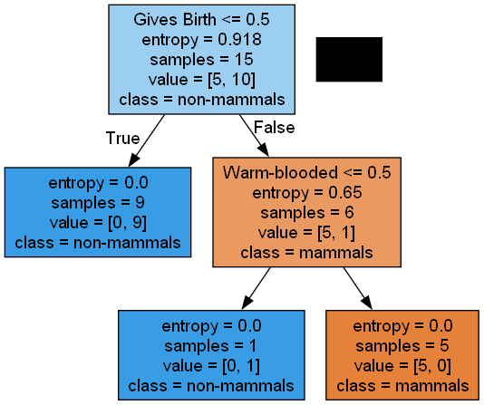

```python
dot_data = tree.export_graphviz(clf_depth3, feature_names=x_train.columns
                , class_names=['mammals','non-mammals'],filled=True)
graph = pydotplus.graph_from_dot_data(dot_data)
Image(graph.create_png())
```

## Q4: Test the decision tree performance on the test set. Use the model from Q2.

Discuss the results.

```python
y_test = df_test["Class"]
x_test = df_test.drop(['Name','Class'],axis=1)

y_pred = clf_depth3.predict(x_test)
```

```python
from sklearn.metrics import confusion_matrix

cm = confusion_matrix(y_test, y_pred)

print(cm)
```

```
[[1 1]
 [0 2]]
```

## HealthScan AI: Enhancing Breast Cancer Diagnosis Accuracy

HealthScan AI is an innovative project undertaken by a consortium of medical researchers, data scientists, and healthcare providers. The project's aim is to develop an advanced machine learning model to improve the accuracy of breast cancer diagnosis, specifically in classifying tumors as benign or malignant. This initiative is particularly crucial in early-stage cancer detection, where accurate diagnosis can significantly impact treatment outcomes and patient survival rates.

Breast cancer diagnosis often relies on mammograms, biopsies, and medical imaging, which sometimes yield ambiguous or inconclusive results. The challenge lies in reducing false positives and negatives, as misclassification can lead to either unnecessary treatments or delayed intervention, respectively.

You are tasked with building predictive model that uses data from the Breast Cancer Dataset, a well-known dataset in medical data analysis. This dataset includes features such as tumor size, shape, and cell characteristics, derived from fine-needle aspirate (FNA) of breast mass. The model aims to classify these tumors as benign or malignant with high accuracy.

You identified that this problem is a classification problem, and researched your options. Decision tree classifiers are only one of the many techniques we can use. Linear classifiers such as logistic regression and support vector machine (SVM) constructs a linear separating hyperplane to distinguish instances from different classes. Using the following questions as a guide post, let's get started by reading the dataset!

```python
from sklearn.datasets import load_breast_cancer
cancer = load_breast_cancer()
```

```python
pd.Series(cancer.target).value_counts()
```

```
1    357
0    212
Name: count, dtype: int64
```

## Q5: Create the independent and dependent datasets, also divide the dataset into train and test.

Use random state = 42. Is there a benefit to using `stratify` parameter?

```python
from sklearn.model_selection import train_test_split

X = cancer.data
y = cancer.target

# Split the dataset into training and testing sets
X_train, X_test, y_train, y_test = train_test_split(X, y, test_size=0.2, random_state=42, stratify=y)
```

The stratify parameter ensures that the train-test split represents the original dataset's distribution of the target variable. This is particularly important for datasets with imbalanced classes in terms of we have 357 VS 212. It ensures that both the training and testing sets have a similar proportion of each class as found in the original dataset. This leads to more reliable evaluation metrics, as the test set will more accurately reflect the performance of the model on unseen data.

## Q6: Train a Logistic Regression model, find the scores of the training and test datasets. Interpret the results.

Caution, when training and test set performances are very close, it is likely we are underfitting. Is your model under- or over-fitting, why?

```python
from sklearn.linear_model import LogisticRegression
# Train a Logistic Regression model
log_reg = LogisticRegression(max_iter=10000, random_state=42)
log_reg.fit(X_train, y_train)

# Find the scores of the training and test datasets
train_score = log_reg.score(X_train, y_train)
test_score = log_reg.score(X_test, y_test)

train_score, test_score
```

```
(0.9582417582417583, 0.9649122807017544)
```

Noticed that the accuracy on the training set is slightly lower than the accuracy on the test set, and both scores are high. as training and test set performance are very close, we can suspect the model may be underfitting.

## Can regularization improve our metrics? Using Ridge and Lasso

Most of the time there is discrepancy between performance on the training set and the test set, which may be an indication of under- or over-fitting. When suspected, Ridge and Lasso Regression models are used.

Ridge regression formula makes predictions the same way as ordinary least squares (linear regression). However in Ridge regression there is a penalty term employed to avoid overfitting, as a result it produces a more restricted model. When Ridge training set score is less than the Linear Regression model training set score, and Ridge test set score is higher than the Linear Regression model test set score, we can conclude that Linear Model is overfitting. If this is the case, you should proceed with Ridge model since it generalizes better (based on the higher test score).

Ridge balances model simplicity and training score (The simpler the model, the smaller the training score would be) using parameter `alpha`. Higher `alpha` values result in smaller coefficients. You can test multiple `alpha` values in your analysis. In sklearn implementation you will see the parameter `C`, which is `1/alpha`.

Lasso also has a penalty term, and some features are entirely ignored by the model by setting coefficients of those features to 0. This is helpful in identifying which features are important , and with any reduction in feature size, the model also may become more interpretable.

## Q7: By varying the regularization coefficient C (1/alpha), find the best model (test both the training and test datasets)

Higher values of C results in more flexible models.

```python
# YOUR CODE HERE
C = [0.01, 1, 10, 100]

# Dictionary to hold accuracy scores for each C value
trainAcc = []
testAcc = []

# Iterate over different C values to train the Logistic Regression model
for C_val in C:
    log_reg = LogisticRegression(C=C_val, max_iter=10000, random_state=42)
    log_reg.fit(X_train, y_train)

    # Evaluate the model on both the training and test sets
    train_accuracy = log_reg.score(X_train, y_train)
    test_accuracy = log_reg.score(X_test, y_test)

    # Store the accuracy scores
    trainAcc.append(train_accuracy)
    testAcc.append(test_accuracy)
```

If you stored the accuracy scores in trainAcc and testAcc for training scores and test scores for varying C levels, you may have a plot like this:

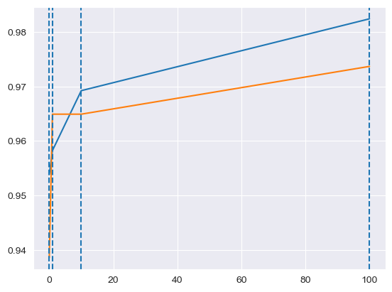

```python
import matplotlib.pyplot as plt

plt.plot(C,trainAcc)
plt.plot(C,testAcc)
for param in C:
    plt.axvline(x=param, ymin=0, ymax=1, linestyle='dashed')

plt.show()
```

The default value C=1 provides a good performance with 95% accuracy on both the training and the test dataset. But as training and test set performance are very close, we can suspect the model may be underfitting. With the last question, we tested multiple C values, by increasing the value of C we enabled the model to be more flexible.

Increasing C=100 has higher training set accuracy, and slightly increased test accuracy as well. The graph shows it is a good idea to increase C to build a more complex model.

By testing C=0.01, the training and test scores are similar, and decreasing the value of C (less flexible model) still underfits the data.

Let's wrap up with a plot the coefficients of our best model, which shows the feature importance.

```python
coef = LogisticRegression(C = 100, max_iter= 10000, random_state=42).fit(X_train, y_train).coef_
```

```python
coef.T
```

```
array([[ 3.87447307e+00],
       [ 4.36445483e-02],
       [-3.36500346e-01],
       [-9.91458711e-03],
       [-4.35004451e+00],
       [ 1.26309059e+00],
       [-3.53548348e+00],
       [-6.78442901e+00],
       [-6.85703474e+00],
       [ 9.03518825e-01],
       [ 1.23206681e+00],
       [ 2.28189726e+00],
       [-4.59175521e-01],
       [-1.19545122e-01],
       [-6.83419154e-01],
       [ 6.57880335e+00],
       [ 8.36010673e+00],
       [-5.26575611e-01],
       [ 7.11993648e-01],
       [ 1.17458194e+00],
       [ 4.93669965e-01],
       [-4.39029949e-01],
       [ 4.76814414e-02],
       [-2.31295608e-02],
       [-8.81498253e+00],
       [ 3.10653966e+00],
       [-4.54282328e+00],
       [-1.44753954e+01],
       [-1.08969985e+01],
       [ 1.31405792e+00]])
```

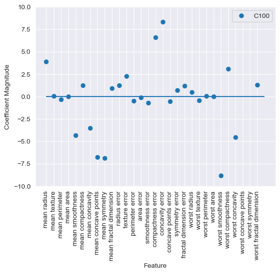

```python
plt.plot(coef.T,'o',label='C100')
plt.xticks(range(cancer.data.shape[1]),cancer.feature_names,rotation=90)
plt.hlines(0,0,cancer.data.shape[1])
plt.ylim(-10,10)
plt.xlabel("Feature")
plt.ylabel('Coefficient Magnitude');
plt.legend()
```

**Assignment 3 Complete!**